# introposter

### Check-In : introduction outlines

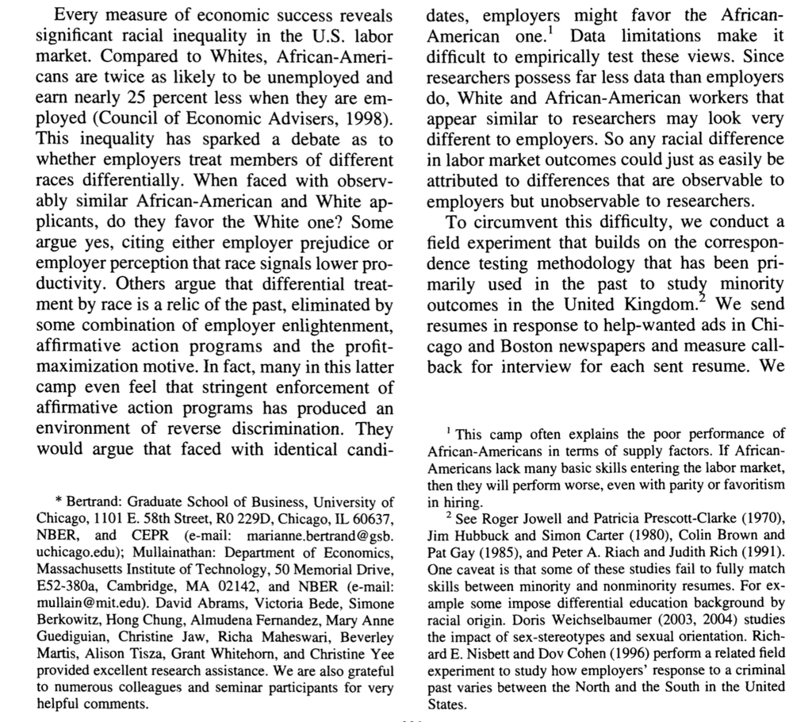

### KEY IDEA : patterns in writing

[figure not shown]

1. **THE POINT :** What are you trying to say?
2. **THE EVIDENCE :** What is some evidence that supports this point?
3. **WHO CARES :** Why does this matter?

### ACTIVITY (STEP 2) : identify parts of an introduction.

[figure not shown]

1. **THE POINT :** What are you trying to say?
2. **THE EVIDENCE :** What is some evidence that supports this point? This could be empirical (e.g., a summary of past research on the topic), but also logic or real-life experiential examples work here.
3. **WHO CARES :** Why does this matter? How does this connect to your main thesis?

### KEY IDEA : evidence can be logic or empirical

*“Think first of swallowing the saliva in your mouth, or do so. Then imagine expectorating it into a tumbler and drinking it! What seemed natural and”mine” suddenly becomes disgusting and alien. Or picture your self sucking blood from a prick in your finger; then imagine sucking blood from a bandage around your finger! What I perceive as separate from my body becomes, in the twinkling of an eye, cold and foreign.”*

- Gordon Allport (1955). Becoming: basic considerations for a psychology of personality. Yale University Press.

In a study of 45 female college students, a sweaty shirt was rated as more disgusting when it was associated with an outgroup than when associated with an ingroup (Reicher et al., 2016).

- S.D. Reicher, A. Templeton, F. Neville, L. Ferrari, & J. Drury, Core disgust is attenuated by ingroup relations, Proc. Natl. Acad. Sci. U.S.A. 113 (10) 2631-2635, https://doi.org/10.1073/pnas.1517027113 (2016).

## ACTIVITY : start outlining your introduction

**The Opening :**

1. What is your topic :
2. What evidence (past research) has been done on this :
3. Why do we / should we care :

**Past Research on IV1 :**

1. What is one variable you think might influence the DV?
2. What evidence (past research) has been done on this IV (and its relation to the DV)?
3. Why do we / should we care?

## Check-In : More Interaction Effects

**Graph A**

[figure not shown]

**Graph B**

[figure not shown]

## Check-In Review (Graph A)

[figure not shown]

The similar effect of stress at the various levels of each standard control variable (i.e., the lack of interaction between stress and each control variable) has already been mentioned. Of special importance in interpreting this study is the fact that stress had the same effects in all the challenge-virus groups regardless of the infectious status of apartment mates or prechallenge serologic status.

## Check-In Review (Graph B)

[figure not shown]

## PART 1 : REVIEWING YOUR INTERACTION EFFECTS

- [**Final Project Description and Rubric**](https://docs.google.com/document/d/1QJKm9s8WUXAoYACf_pC9QIWdYyfEOHQNMnP4unkXGYI/edit?usp=sharing)

[figure not shown]

## PART 3 : METHODS

### EXAMPLE 1. Well-Being

[figure not shown]

what is the measure? (self-report or observation) how is this measure reliable? (test-retest; inter-item; inter-judge; etc.) how is this measure valid? (face validity; convergent validity; etc.)

### EXAMPLE 2. Smiling

[figure not shown]

what is the measure? (self-report or observation) how is this measure reliable? (test-retest; inter-item; inter-judge; etc.) how is this measure valid? (face validity; convergent validity; etc.)

## NEXT WEEK : Milestone 3

- Intro Outline
- Measure Draft
- Whew.

## NEXT WEEK : More Project Time

[figure not shown]